# Illustration avec des figures générées par du code

## Exemple d'application : les fonctions de plusieurs variables

```python
import numpy as np
import matplotlib.pyplot as plt
from mpl_toolkits.mplot3d import Axes3D
from matplotlib import cm
```

**Exemples du cours :**

1) **Courbe représensentative (classique) :**

$ \ \ \ \ f : \mathbb{R} \rightarrow \mathbb{R}$

$ \ \ \ \ f : x \mapsto x \sin(x)$

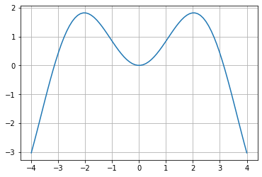

```python
%matplotlib inline

def f(x):
    return x*np.sin(x)

x = np.linspace(-4,4,80)

plt.plot(x,f(x))
plt.grid(True)
plt.show()
```

2) **Courbe paramétrée :**

Rappel : Coordonnées cartésiennes d'un point $M$ en fonction de l’angle polaire $\theta$. On obtient :

$$ x = r \cos (\theta) = f(\theta) \cos(\theta) $$$$ y=r \sin (\theta) = f(\theta) \sin(\theta)$$

**Exemple 1** : Prenons l'exemple d'une cardioïde, qui est une courbe paramétrée ayant pour paramètre $\theta$ d'équation :

$ \ \ \ \ f : \mathbb{R} \rightarrow \mathbb{R}$

$ \ \ \ \ f : \theta \mapsto r = f(\theta) = a (1+ \cos(\theta))$

On prendra $a=1$ dans cet exemple.

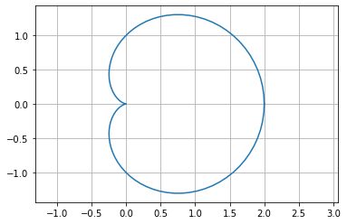

```python
Theta = np.linspace(0, 2*np.pi, 100) # tableau numpy 1D des angles theta
a = 1
R = a*( 1 + np.cos(Theta) ) # tableau numpy 1D des rayons r
X = R*np.cos(Theta) # tableau numpy 1D des abscisses x
Y = R*np.sin(Theta) # tableau numpy 1D des ordonnées y
plt.figure(1)
plt.axis("equal") # axes de longueurs égales
plt.plot(X, Y) # tracé de la courbe polaire
plt.grid(True)
plt.show()
```

**Exemple 2 :**

$ \ \ \ \ f : \mathbb{R} \rightarrow \mathbb{R}^3$

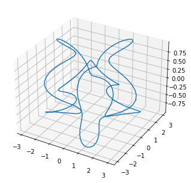

```python
%matplotlib inline
ax = Axes3D(plt.figure())
T = np.linspace(0,4.*np.pi,200)
X = (2 + np.cos(5.5 * T)) * np.cos(T)
Y = (2 + np.cos(5.5 * T)) * np.sin(T)
Z = np.sin(1.5 * T)
ax.plot(X, Y, Z)
plt.show()
```

3) **Surface représentative :**

$ \ \ \ \ f : \mathbb{R}^2 \rightarrow \mathbb{R}$

$ \ \ \ \ f : (x,y) \mapsto x y \ e^{(-x^2-y^2)}$

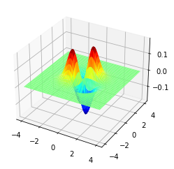

```python
%matplotlib inline
fig = plt.figure()
ax = fig.add_subplot(111, projection='3d')

def f(x,y):
    return x * y * np.exp((-x**2 - y**2))

x = np.linspace(-4,4,150)
y = np.linspace(-4,4,150)

x, y = np.meshgrid(x, y)
ax.plot_surface(x, y, f(x, y), cmap=cm.jet)
plt.show()
```

**Lignes de niveaux associées à la surface ci-dessus**

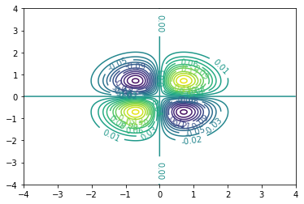

```python
cont=plt.contour(x, y, f(x,y),35)
plt.clabel(cont,fmt='%3.2f')
plt.show()
```

4) **Surface paramétrique :**

$ \ \ \ \ f : \mathbb{R}^2 \rightarrow \mathbb{R}^3$

$ \ \ \ \ f : (u,v) \mapsto \bigl (2 + \sin(v))\cos(u), \ (2 + \sin(v))\sin(u), \ u + \cos(v) \bigr )$

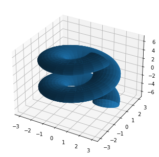

```python
%matplotlib inline
ax = Axes3D(plt.figure())

u = np.linspace(-6,6,200)
v = np.linspace(-6,6,200)
u, v = np.meshgrid(u, v)

X = (2 + np.sin(v)) * np.cos(u)
Y = (2 + np.sin(v)) * np.sin(u)
Z = u + np.cos(v)

ax.plot_surface(X, Y, Z)
plt.show()
```

5) **Champ vectoriel (en 2D) :**

$ \ \ \ \ f : \mathbb{R}^2 \rightarrow \mathbb{R}^2$

$ \ \ \ \ f : (x,y) \mapsto (\cos(x), \sin(y))$

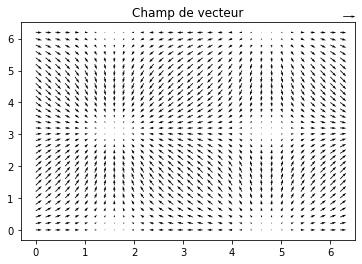

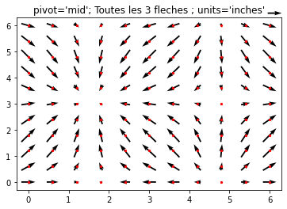

```python
# en python, on trace des champs de vecteurs avec des flèches grace à la fonction "quiver" de matplotlib
%matplotlib inline
X, Y = np.meshgrid(np.arange(0, 2 * np.pi, .2), np.arange(0, 2 * np.pi, .2))
U = np.cos(X)
V = np.sin(Y)

# Champ de vecteur où les fleches sont mises a l'echelle en fonction du graphe
plt.figure()
plt.title('Champ de vecteur')
Q = plt.quiver(X, Y, U, V, units='width')
qk = plt.quiverkey(Q, 0.9, 0.9, 2, r'$2 \frac{m}{s}$', labelpos='E',
                   coordinates='figure')

# Même champ de vecteur mais où on ne trace qu'une flèche sur 3
plt.figure()
plt.title("pivot='mid'; Toutes les 3 fleches ; units='inches'")
Q = plt.quiver(X[::3, ::3], Y[::3, ::3], U[::3, ::3], V[::3, ::3],
               pivot='mid', units='inches')
qk = plt.quiverkey(Q, 0.9, 0.9, 1, r'$1 \frac{m}{s}$', labelpos='E',
                   coordinates='figure')
plt.scatter(X[::3, ::3], Y[::3, ::3], color='r', s=5)

plt.show()
```

5) **Champ vectoriel (en 3D) :**

$ \ \ \ \ f : \mathbb{R}^3 \rightarrow \mathbb{R}^3$

$ \ \ \ \ f : (x,y,z) \mapsto (\sin(\pi x) \cos(\pi y) \cos(\pi z), -\cos(\pi x) \sin(\pi y) \cos(\pi z), \sqrt{\frac{2}{3}} \cos(\pi x) \cos(\pi y) \sin(\pi z))$

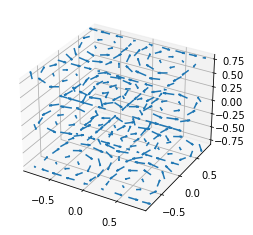

```python
from mpl_toolkits.mplot3d import axes3d
import matplotlib.pyplot as plt
import numpy as np

fig = plt.figure()
ax = fig.gca(projection='3d')

x, y, z = np.meshgrid(np.arange(-0.8, 1, 0.2),
                      np.arange(-0.8, 1, 0.2),
                      np.arange(-0.8, 1, 0.8))

u = np.sin(np.pi * x) * np.cos(np.pi * y) * np.cos(np.pi * z)
v = -np.cos(np.pi * x) * np.sin(np.pi * y) * np.cos(np.pi * z)
w = (np.sqrt(2.0 / 3.0) * np.cos(np.pi * x) * np.cos(np.pi * y) *
     np.sin(np.pi * z))

# on peut changer la longueur des flèches (quiver en anglais) en changeant la valeur du paramètre length
ax.quiver(x, y, z, u, v, w, length=0.2)

plt.show()
```

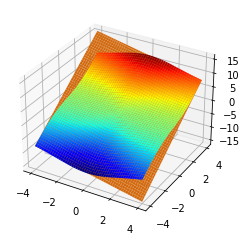

```python
%matplotlib inline
fig = plt.figure()
ax = fig.add_subplot(111, projection='3d')

def f(x,y):
    return (x**2 * y + 3*y**3)  / (x**2 + y**2)

def g(x,y):
    return -x + 3 * y

x = np.linspace(-4,4,150)
y = np.linspace(-4,4,150)

x, y = np.meshgrid(x, y)
ax.plot_surface(x, y, f(x, y), cmap=cm.jet)
ax.plot_surface(x, y, g(x, y))
plt.show()
```